# twitter us airline sentiment analysis - nlp

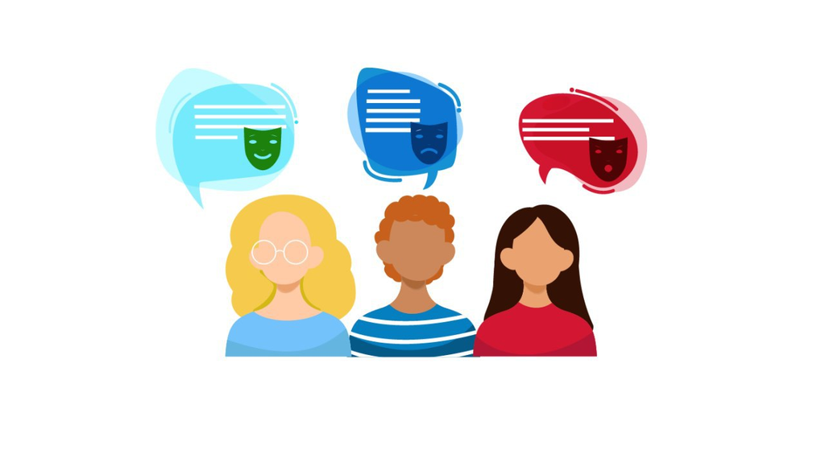

### Background and Context:

Twitter possesses 330 million monthly active users, which allows businesses to reach a broad population and connect with customers without intermediaries. On the other hand, there’s so much information that it’s difficult for brands to quickly detect negative social mentions that could harm their business.

That's why sentiment analysis/classification, which involves monitoring emotions in conversations on social media platforms, has become a key strategy in social media marketing.

Listening to how customers feel about the product/service on Twitter allows companies to understand their audience, keep on top of what’s being said about their brand and their competitors, and discover new trends in the industry.

### Data Description:

A sentiment analysis job about the problems of each major U.S. airline. Twitter data was scraped from February of 2015 and contributors were asked to first classify positive, negative, and neutral tweets, followed by categorizing negative reasons (such as "late flight" or "rude service").

### Dataset:

The dataset has the following columns:

- tweet_id
- airline_sentiment
- airline_sentiment_confidence
- negativereason
- negativereason_confidence
- airline
- airline_sentiment_gold
- name
- negativereason_gold
- retweet_count
- text
- tweet_coord
- tweet_created
- tweet_location
- user_timezone

### Objective:

To implement the techniques learned as a part of the course and do data analysis on the dataset to find the best and the worst airlines and understand what are the most common problems in case of bad flight.

This work can be useful for the airline company to understand what are the problems to working on.

### Learning Outcomes:

Basic understanding of text pre-processing. What to do after text pre-processing Bag of words Tf-idf Build the classification model. Evaluate the Model

### Mount google drive

```python
# mount google drive
from google.colab import drive
drive.mount('/content/drive')
```

### Install required libraries

```python
!pip install contractions
```

```
     |████████████████████████████████| 321 kB 5.2 MB/s
     |████████████████████████████████| 284 kB 39.8 MB/s
```

### Import required libraries

```python
# this will help in making the Python code more structured automatically (good coding practice), comment for colab

# %load_ext nb_black

# library to suppress warnings or deprecation notes
import warnings

warnings.filterwarnings("ignore")

# libraries to help with reading and manipulating data
import pandas as pd
import numpy as np

# import Regex, string and unicodedata.
import re, string, unicodedata

# import contractions library.
import contractions

# import BeautifulSoup.
from bs4 import BeautifulSoup

# import Natural Language Tool-Kit.
import nltk

# download Stopwords.
nltk.download('stopwords')
nltk.download('punkt')
nltk.download('wordnet')

# import stopwords.
from nltk.corpus import stopwords

# import Tokenizer.
from nltk.tokenize import word_tokenize, sent_tokenize

# library to split data
from sklearn.model_selection import train_test_split, StratifiedKFold

# libaries to help with data visualization
import matplotlib.pyplot as plt
import seaborn as sns

# import wordcloud
import wordcloud
from wordcloud import WordCloud

# remove the limit for the number of displayed columns
pd.set_option("display.max_columns", None)

# set the limit for the number of displayed rows
pd.set_option("display.max_rows", 200)

# to get diferent metric scores
from sklearn.metrics import (
    recall_score,
    accuracy_score,
    confusion_matrix,
    f1_score,
    precision_score,
    precision_recall_fscore_support
)

# import vectorizers
from sklearn.feature_extraction.text import CountVectorizer, TfidfVectorizer

# import rfc and cross_val_score
from sklearn.ensemble import RandomForestClassifier
from sklearn.model_selection import cross_val_score

# import word prepocessors
from nltk.tokenize import word_tokenize
from nltk.stem import LancasterStemmer, WordNetLemmatizer

# smote for oversampling data
from imblearn.over_sampling import SMOTE
```

### Define required functions

```python
# histogram and boxplot for the feature
def histogram_boxplot(data, feature, figsize=(12, 7), kde=False, bins=None):
    """
    Boxplot and histogram combined

    data: dataframe
    feature: dataframe column
    figsize: size of figure (default (12,7))
    kde: whether to the show density curve (default False)
    bins: number of bins for histogram (default None)
    """
    f2, (ax_box2, ax_hist2) = plt.subplots(
        nrows=2,  # Number of rows of the subplot grid= 2
        sharex=True,  # x-axis will be shared among all subplots
        gridspec_kw={"height_ratios": (0.25, 0.75)},
        figsize=figsize,
    )  # creating the 2 subplots
    sns.boxplot(
        data=data, x=feature, ax=ax_box2, showmeans=True, color="orange"
    )  # boxplot will be created and a star will indicate the mean value of the column
    sns.histplot(
        data=data, x=feature, kde=kde, ax=ax_hist2, bins=bins, palette="Winter"
    ) if bins else sns.histplot(
        data=data, x=feature, kde=kde, ax=ax_hist2
    )  # For histogram
    ax_hist2.axvline(
        data[feature].mean(), color="green", linestyle="--"
    )  # Add mean to the histogram
    ax_hist2.axvline(data[feature].median(), color="blue", linestyle="-")
    plt.show()  # show the plot

# labeled_barplot
def labeled_barplot(data, feature, perc=False, v_ticks=True, n=None):
    """
    Barplot with percentage at the top

    data: dataframe
    feature: dataframe column
    perc: whether to display percentages instead of count (default is False)
    n: displays the top n category levels (default is None, i.e., display all levels)
    """

    total = len(data[feature])  # length of the column
    count = data[feature].nunique()
    if n is None:
        plt.figure(figsize=(count + 1, 5))
    else:
        plt.figure(figsize=(n + 1, 5))

    if v_ticks is True:
        plt.xticks(rotation=90)

    ax = sns.countplot(
        data=data,
        x=feature,
        palette="Paired",
        order=data[feature].value_counts().index[:n].sort_values(),
    )

    for p in ax.patches:
        if perc == True:
            label = "{:.1f}%".format(
                100 * p.get_height() / total
            )  # percentage of each class of the category
        else:
            label = p.get_height()  # count of each level of the category

        x = p.get_x() + p.get_width() / 2  # width of the plot
        y = p.get_height()  # height of the plot

        ax.annotate(
            label,
            (x, y),
            ha="center",
            va="center",
            size=12,
            xytext=(0, 5),
            textcoords="offset points",
        )  # annotate the percentage
    plt.show()  # show the plot

# function to plot stacked bar chart
def stacked_barplot(data, predictor, target):
    """
    Print the category counts and plot a stacked bar chart

    data: dataframe
    predictor: independent variable
    target: target variable
    """
    count = data[predictor].nunique()
    sorter = data[target].value_counts().index[-1]
    tab1 = pd.crosstab(data[predictor], data[target], margins=True).sort_values(
        by=sorter, ascending=False
    )
    # print(tab1)
    # print("-" * 120)
    tab = pd.crosstab(data[predictor], data[target], normalize="index").sort_values(
        by=sorter, ascending=False
    )
    tab.plot(kind="bar", stacked=True, figsize=(count + 5, 6))
    plt.legend(
        loc="lower left", frameon=False,
    )
    plt.legend(loc="upper left", bbox_to_anchor=(1, 1))
    plt.show()

# to plot confusion matrix
def draw_matrix(model, predictors, target):
    """
    To plot the confusion_matrix with percentages

    model: classifier
    predictors: independent variables
    target: dependent variable
    """
    y_pred = model.predict(predictors)
    cm = confusion_matrix(target, y_pred)
    labels = np.asarray(
        [
            ["{0:0.0f}".format(item) + "\n{0:.2%}".format(item / cm.flatten().sum())]
            for item in cm.flatten()
        ]
    ).reshape(3, 3)

    plt.figure(figsize=(10, 6))
    x_axis_labels = ['Negative', 'Neutral', 'Positive'] # labels for x-axis
    y_axis_labels = ['Negative', 'Neutral', 'Positive'] # labels for y-axis
    sns.heatmap(cm, annot=labels, fmt="", xticklabels=x_axis_labels, yticklabels=y_axis_labels)
    plt.ylabel("True label")
    plt.xlabel("Predicted label")
    plt.show()
```

### Load the dataset

```python
# load data from csv
df = pd.read_csv("/content/drive/MyDrive/module-10/project/Tweets.csv")

# back up data to preserve the initial version for reference
df_back = df.copy()
```

#### Check the shape of data

```python
# print the data set information as number of rows and columns
print(f"There are {df.shape[0]} rows and {df.shape[1]} columns.")  # f-string
```

```
There are 14640 rows and 15 columns.
```

#### Check the dataset information

```python
# check the dataset information
df.info()
```

```
<class 'pandas.core.frame.DataFrame'>
RangeIndex: 14640 entries, 0 to 14639
Data columns (total 15 columns):
 #   Column                        Non-Null Count  Dtype
---  ------                        --------------  -----
 0   tweet_id                      14640 non-null  int64
 1   airline_sentiment             14640 non-null  object
 2   airline_sentiment_confidence  14640 non-null  float64
 3   negativereason                9178 non-null   object
 4   negativereason_confidence     10522 non-null  float64
 5   airline                       14640 non-null  object
 6   airline_sentiment_gold        40 non-null     object
 7   name                          14640 non-null  object
 8   negativereason_gold           32 non-null     object
 9   retweet_count                 14640 non-null  int64
 10  text                          14640 non-null  object
 11  tweet_coord                   1019 non-null   object
 12  tweet_created                 14640 non-null  object
 13  tweet_location                9907 non-null   object
 14  user_timezone                 9820 non-null   object
dtypes: float64(2), int64(2), object(11)
memory usage: 1.7+ MB
```

**Observations:**

1. There are 15 columns in the dataset.
2. Half of the columns have null values. Considering both dependent and independent variables not having any null values, we will not do any null value processing.
3. Most columns in the dataset are of object type.
4. airline_sentiment is our dependent / target variable.
5. text column is our independent variable that we will use for analysis.
6. All other columns will be dropped at a later stage.

#### Check for duplicates

```python
# print the data set information as number of rows and columns
print(f"There are {df.duplicated().sum()} duplicate records in the datset.")  # f-string
```

```
There are 36 duplicate records in the datset.
```

#### Drop the duplicates

```python
# use drop_duplicates
df.drop_duplicates(inplace = True)
# print the data set information as number of rows and columns
print(f"There are {df.duplicated().sum()} duplicate records in the datset.")  # f-string
```

```
There are 0 duplicate records in the datset.
```

#### Check the sample data

```python
# setting the random seed via np.random.seed to get the same random results every time
np.random.seed(1)

# also look at random 10 sample rows
df.sample(n=10)
```

|  | tweet_id | airline_sentiment | airline_sentiment_confidence | negativereason | negativereason_confidence | airline | airline_sentiment_gold | name | negativereason_gold | retweet_count | text | tweet_coord | tweet_created | tweet_location | user_timezone |
| --- | --- | --- | --- | --- | --- | --- | --- | --- | --- | --- | --- | --- | --- | --- | --- |
| 7423 | 569618309357940737 | neutral | 0.6427 | NaN | NaN | Delta | NaN | ChrisDonahoe | NaN | 0 | @JetBlue the fact that #ChrisHasMadeUsBLUSH is... | NaN | 2015-02-22 14:02:42 -0800 | Washington, D.C. | Quito |
| 7684 | 569346428839063552 | positive | 1.0000 | NaN | NaN | Delta | NaN | karaackerman | NaN | 0 | @JetBlue thank you | NaN | 2015-02-21 20:02:21 -0800 | New York City | Quito |
| 14553 | 569600462661554177 | negative | 1.0000 | Customer Service Issue | 0.6887 | American | NaN | otisday | NaN | 0 | @AmericanAir @tennetexan Too bad there's only,... | NaN | 2015-02-22 12:51:47 -0800 | Pekin | Eastern Time (US & Canada) |
| 1524 | 569683567552262145 | negative | 1.0000 | Bad Flight | 0.3492 | United | NaN | FernHeinig18 | NaN | 0 | @united, you just caused a riot on the airplan... | NaN | 2015-02-22 18:22:01 -0800 | NaN | NaN |
| 11868 | 567722301471199232 | negative | 1.0000 | Customer Service Issue | 1.0000 | US Airways | NaN | CharNewsJunkie | NaN | 0 | @USAirways Almost 4 hours and coin now. Unders... | NaN | 2015-02-17 08:28:39 -0800 | Charlotte, North Carolina | Eastern Time (US & Canada) |
| 663 | 570214660638511104 | positive | 0.6632 | NaN | 0.0000 | United | NaN | BouleChitte | NaN | 0 | @united private jet would have been cool! Do d... | NaN | 2015-02-24 05:32:23 -0800 | NaN | NaN |
| 8244 | 568560914779078656 | positive | 1.0000 | NaN | NaN | Delta | NaN | dcooode | NaN | 0 | @JetBlue Although it wasn't totally the answer... | NaN | 2015-02-19 16:01:00 -0800 | NaN | NaN |
| 10977 | 568644286306242561 | neutral | 0.6401 | NaN | NaN | US Airways | NaN | jrfigo | NaN | 0 | @USAirways I am following you now | NaN | 2015-02-19 21:32:17 -0800 | NaN | NaN |
| 12688 | 570060846241611777 | positive | 1.0000 | NaN | NaN | American | NaN | NickWellen | NaN | 0 | @AmericanAir thanks | NaN | 2015-02-23 19:21:11 -0800 | Minnesota | NaN |
| 13359 | 569881888892055552 | negative | 1.0000 | Customer Service Issue | 1.0000 | American | NaN | gdelgadillo | NaN | 0 | @AmericanAir I've been calling your 1800 # all... | NaN | 2015-02-23 07:30:04 -0800 | Brklyn by way of San Franciso | Eastern Time (US & Canada) |

**Observations:**

1. We see there are lot of missing values in the dataset. Since the two variables that required for our model building doesnt have missing values, we will not be handling those.
2. All other data looks ok and relevant to domain.
3. We will further look at data during EDA.

#### Describe the data

```python
# describe data
df.describe().T
```

|  | count | mean | std | min | 25% | 50% | 75% | max |
| --- | --- | --- | --- | --- | --- | --- | --- | --- |
| tweet_id | 14604.0 | 5.692157e+17 | 7.782567e+14 | 5.675883e+17 | 5.685581e+17 | 5.694728e+17 | 5.698885e+17 | 5.703106e+17 |
| airline_sentiment_confidence | 14604.0 | 8.999228e-01 | 1.629550e-01 | 3.350000e-01 | 6.923000e-01 | 1.000000e+00 | 1.000000e+00 | 1.000000e+00 |
| negativereason_confidence | 10503.0 | 6.376440e-01 | 3.303799e-01 | 0.000000e+00 | 3.605000e-01 | 6.705000e-01 | 1.000000e+00 | 1.000000e+00 |
| retweet_count | 14604.0 | 8.278554e-02 | 7.466473e-01 | 0.000000e+00 | 0.000000e+00 | 0.000000e+00 | 0.000000e+00 | 4.400000e+01 |

**Observations:**

## Exploratory data analysis

#### Distribution of tweets accross airlines

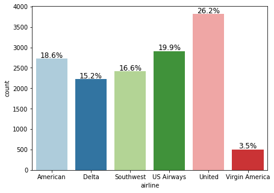

```python
# use label_barplot function to plot the graph
labeled_barplot(df,"airline", True, False)
```

**Observations:**

#### Distribution of sentiment accross all tweets

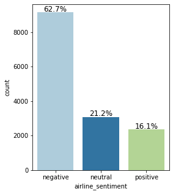

```python
# use label_barplot function to plot the graph
labeled_barplot(df,"airline_sentiment", True, False)
```

**Observations:**

1. The dataset is heavily imbalanced with almost 63% data being negative tweets.
2. 21.2% tweets are neutral.
3. 16% tweets are positive.

#### Distribution of Sentiment of tweets for each airline

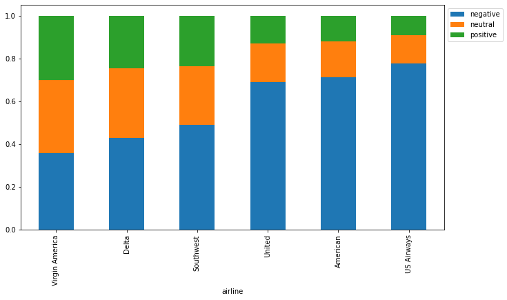

```python
# use the defined function stacked_barplot to plot the graphs
stacked_barplot(df, "airline", "airline_sentiment")
```

**Observations:**

1. US Airways has most negative reviews and lease positve reviews.
2. American and United has almost similar % of negative reviews.
3. Virgin America has most postive and neutral reviews.

#### Distribution of all the negative reasons

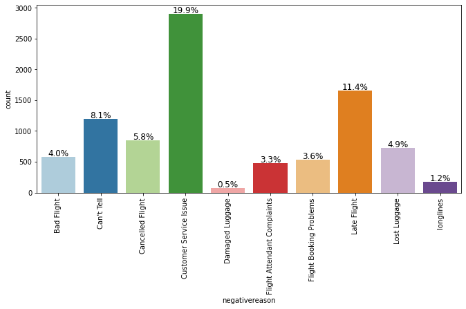

```python
# use label_barplot function to plot the graph
labeled_barplot(df,"negativereason", True, True)
```

Observations:

1. "Customer Service Issue" is the most twitted negative reason, contributing to 19.9% of the data.
2. "Late Flight" is the second most negative reason.
3. "Damaged Luggage" is the least twitted negative reason.

#### Distribution of negativereason per airline

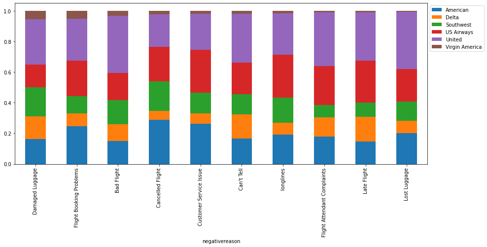

```python
# use the defined function stacked_barplot to plot the graphs
stacked_barplot(df, "negativereason", "airline")
```

**Observations:**

1. Here we can see that United Airlines, US Airways, American Airlines has the most number of negative review
2. Virgin America has the least number of negative reviews
3. Customer service and Late flight seems to be the main reason why customers are giving bad feedback

#### Split the text data into sentiments

```python
# Split text of Sentiments
positive = df[df['airline_sentiment'] == 'positive'].text
neutral  = df[df['airline_sentiment'] == 'neutral'].text
negative  = df[df['airline_sentiment'] == 'negative'].text
```

#### Word cloud graph of tweets for positive sentiments

```
(-0.5, 2999.5, 2499.5, -0.5)
```

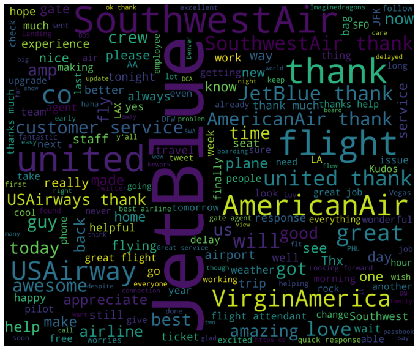

```python
# world could of positive sentiments
plt.figure(figsize = (12,12))
worldcould_pos = WordCloud(width = 3000 , height = 2500).generate(" ".join(positive))
plt.imshow(worldcould_pos,interpolation = 'bilinear')
plt.axis('off')
```

**Observations:**

good, best, great, appreciate, better are few of the positive words that appear in the postive reviews.

#### Word cloud graph of tweets for negative sentiments

```
(-0.5, 2999.5, 2499.5, -0.5)
```

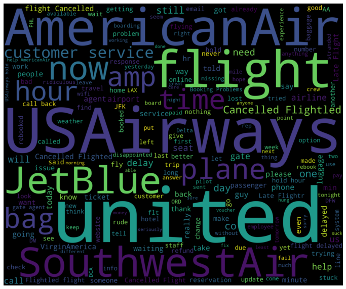

```python
# world could of negative sentiments
plt.figure(figsize = (12,12))
worldcould_neg = WordCloud(width = 3000 , height = 2500).generate(" ".join(negative))
plt.imshow(worldcould_neg,interpolation = 'bilinear')
plt.axis('off')
```

**Observations:**

refund, deplayed, stranded, cancelled, waiting, stuck are few words that appear in the negative reviews.

### Understanding the data columns

#### Print the list of columns

```python
# display the list of columns
df.columns
```

```
Index(['tweet_id', 'airline_sentiment', 'airline_sentiment_confidence',
       'negativereason', 'negativereason_confidence', 'airline',
       'airline_sentiment_gold', 'name', 'negativereason_gold',
       'retweet_count', 'text', 'tweet_coord', 'tweet_created',
       'tweet_location', 'user_timezone'],
      dtype='object')
```

#### Drop the columns other than text and airline_sentiment

```python
# let us now remove irrelevant columns
tweets = df.drop(['tweet_id', 'airline_sentiment_confidence',
       'negativereason', 'negativereason_confidence', 'airline',
       'airline_sentiment_gold', 'name', 'negativereason_gold',
       'retweet_count','tweet_coord', 'tweet_created',
       'tweet_location', 'user_timezone'], axis =1)
```

#### Shape of data

```python
# print the data set information as number of rows and columns
print(f"There are {tweets.shape[0]} rows and {tweets.shape[1]} columns.")  # f-string
```

```
There are 14604 rows and 2 columns.
```

#### Check the sample records

```python
# look at first 5 records
tweets.head()
```

|  | airline_sentiment | text |
| --- | --- | --- |
| 0 | neutral | @VirginAmerica What @dhepburn said. |
| 1 | positive | @VirginAmerica plus you've added commercials t... |
| 2 | neutral | @VirginAmerica I didn't today... Must mean I n... |
| 3 | negative | @VirginAmerica it's really aggressive to blast... |
| 4 | negative | @VirginAmerica and it's a really big bad thing... |

```python
# print distinch value counts of sentiments
print(tweets.airline_sentiment.value_counts())
```

```
negative    9159
neutral     3091
positive    2354
Name: airline_sentiment, dtype: int64
```

**Observations:**

1. We can see all sentiments in the sample.
2. There data is not balanced, the percentage of negative sentiment is high.
3. There are 14604 rows in the dataset after duplicate data cleanup.

### Data Pre-processing

#### Html tag removal

```python
# define function for html cleanup
def perform_html_cleanup(raw_review):
  review_text = BeautifulSoup(raw_review).get_text()
  return review_text
```

#### Replace Contraction

```python
# define functions to replace contractions
def replace_contractions(raw_review):
    return contractions.fix(raw_review)
```

#### Tokenization

```python
# define functions for tokenization
def perform_tokenization(raw_review):
  word_tokens = word_tokenize(raw_review)  # Tokenization
  return word_tokens
```

#### Removal of numbers

```python
# define function for removing numbers
def remove_numbers(list_of_words):
    pattern = '[0-9]'
    list = [re.sub(pattern, '', i) for i in list_of_words]
    return list
```

#### Removal of Special Characters

```python
# define functions for special characters
def remove_special_character(list_of_words):
    pattern = '[^A-Za-z0-9]+'
    list = [re.sub(pattern, '', i) for i in list_of_words]
    return list
```

#### Removal of Punctuations

```python
# define function to remove punctuation
def remove_punctuation(words):
    """Remove punctuation from list of tokenized words"""
    new_words = []                        # Create empty list to store pre-processed words.
    for word in words:
        new_word = re.sub(r'[^\w\s]', '', word)
        if new_word != '':
            new_words.append(new_word)    # Append processed words to new list.
    return new_words
```

#### Removal of stopwords

```python
# define the function to remove the stop words
def remove_stopwords(words):
    """Remove stop words from list of tokenized words"""
    stoplist = set(stopwords.words("english"))
    new_words = []
    for word in words:
        if word not in stoplist:
            new_words.append(word)
    return new_words
```

#### Conversion to lowercase

```python
# define function to converting to lowercase
def to_lowercase(words):
    """Convert all characters to lowercase from list of tokenized words"""
    new_words = []                        # Create empty list to store pre-processed words.
    for word in words:
        new_word = word.lower()           # Converting to lowercase
        new_words.append(new_word)        # Append processed words to new list.
    return new_words
```

#### Removal of empty strings

```python
# define function to remove the empty strings
def remove_empty_string(words):
  return list(filter(None, words))
```

#### Lemmatize

```python
# define function for lematizing
def lemmatize_verbs(words):
    """Lemmatize verbs in list of tokenized words"""
    lemmatizer = WordNetLemmatizer()
    lemmas = []                           # Create empty list to store pre-processed words.
    for word in words:
        lemma = lemmatizer.lemmatize(word, pos='v')
        lemmas.append(lemma)              # Append processed words to new list.
    return lemmas
```

#### Stemming

```python
# define function for stemming
def stem_words(words):
    """Stem words in list of tokenized words"""
    stemmer = LancasterStemmer()
    stems = []                            # Create empty list to store pre-processed words.
    for word in words:
        stem = stemmer.stem(word)
        stems.append(stem)                # Append processed words to new list.
    return stems
```

#### Define driver function for pre processing

```python
# define a cleanup function to call all the preprocessors sequentially.
def perform_cleanup(raw_review):
    clean_review = perform_html_cleanup(raw_review)
    clean_review = replace_contractions(clean_review)
    clean_review = perform_tokenization(clean_review)
    clean_review = remove_numbers(clean_review)
    clean_review = remove_special_character(clean_review)
    clean_review = remove_punctuation(clean_review)
    clean_review = remove_stopwords(clean_review)
    clean_review = to_lowercase(clean_review)
    clean_review = remove_empty_string(clean_review)
    # clean_review = stem_words(clean_review) # we will lemmatize data as we dont have too many records for larger datasets stem_words can be used
    clean_review = lemmatize_verbs(clean_review)
    return clean_review
```

#### Join the words in the list to convert back to text string in the data frame.

(So that each row contains the data in text format.)

```python
# empty list
clean_reviews = []

# loop through the data and cleanup and join
for i, row in tweets.iterrows():
    words = tweets.at[i, 'text']
    words = perform_cleanup(words)
    tweets.at[i,'text'] = " ".join(words)
    clean_reviews.append(tweets.at[i, 'text'])
```

#### Sample data

```python
# display first 5 rows
tweets.head()
```

|  | airline_sentiment | text |
| --- | --- | --- |
| 0 | neutral | virginamerica what dhepburn say |
| 1 | positive | virginamerica plus add commercials experience ... |
| 2 | neutral | virginamerica i today must mean i need take an... |
| 3 | negative | virginamerica really aggressive blast obnoxiou... |
| 4 | negative | virginamerica really big bad thing |

### Vectorization

#### CountVectorizer

```python
# instantiate CountVectorizer with 5000 features
count_vectorizer = CountVectorizer(analyzer = "word",
                             tokenizer = None,
                             preprocessor = None,
                             stop_words = None,
                             max_features = 5000)
# fit the vectorizer
data_features_cv = count_vectorizer.fit_transform(clean_reviews)

# convert the features to array
data_features_cv = data_features_cv.toarray()
```

#### TfidfVectorizer

```python
# using TfidfVectorizer to convert text data to numbers.

# instantiate vectorizer with 5000 features and min_df and max_df
tfidf_vectorizer = TfidfVectorizer(analyzer = "word",
                             tokenizer = None,
                             preprocessor = None,
                             stop_words = None,
                             max_features = 5000,
                             min_df=5,
                             max_df=0.7,
                             ngram_range=(1,2))

# fit the vectorizer
data_features_tfidf = tfidf_vectorizer.fit_transform(clean_reviews)

# convert the features to array
data_features_tfidf = data_features_tfidf.toarray()
```

### Split the data and prepare for model building

```python
# dependent variable
x_cv = data_features_cv
x_tfidf = data_features_tfidf
y = tweets['airline_sentiment']

# countvectorized data
X_train_cv, X_test_cv, y_train_cv, y_test_cv = train_test_split(x_cv, y, test_size=0.3, random_state=1)

# tfidf_vectorized data
X_train_tfidf, X_test_tfidf, y_train_tfidf, y_test_tfidf = train_test_split(x_tfidf, y, test_size=0.3, random_state=1)
```

### Model building

#### RandomForestClassifier with CountVectorized dataset

```python
# Using Random Forest to build model for the classification of reviews.
forest_cv = RandomForestClassifier(n_estimators=10, n_jobs=4)

# fit the model
forest_cv = forest_cv.fit(X_train_cv, y_train_cv)

# print the score
print("Score on training set")
print(forest_cv.score(X_train_cv,y_train_cv))

# check cross validation score
print("Mean CVScore on training set")
print(np.mean(cross_val_score(forest_cv, x_cv, y, cv=10)))
```

```
Score on training set
0.9807278419096067
Mean CVScore on training set
0.713160904990952
```

#### Score the model on test set

```python
# print the score
print("Score on test set")
print(forest_cv.score(X_test_cv,y_test_cv))
```

```
Score on test set
0.7311729803742584
```

#### Plot confusion matrix

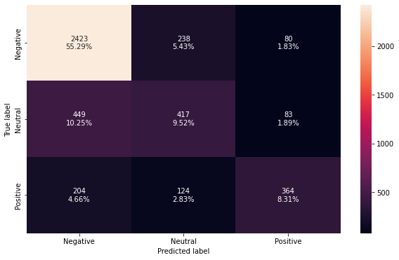

```python
# plot confusion matrix
draw_matrix(forest_cv,X_test_cv,y_test_cv)
```

**Observations:**

1. We see that the model gives higher accuracy on training set.
2. On the test set the model gives 73% accuracy.
3. Let us build another model with TfIdfVectorizer data.

#### RandomForestClassifier with TFIDFVectorized dataset

```python
# Using Random Forest to build model for the classification of reviews.
forest_tfidf = RandomForestClassifier(n_estimators=10, n_jobs=4)

# fit the model
forest_tfidf = forest_tfidf.fit(X_train_tfidf, y_train_tfidf)

# print the score
print("Score on training set")
print(forest_tfidf.score(X_train_tfidf,y_train_tfidf))

# check cross validation score
print("Mean CVScore on training set")
print(np.mean(cross_val_score(forest_tfidf, x_tfidf, y, cv=10)))
```

```
Score on training set
0.9752494619448249
Mean CVScore on training set
0.7022030322635088
```

#### Score the model on test set

```python
# print the score
print("Score on test set")
print(forest_tfidf.score(X_test_tfidf,y_test_tfidf))
```

```
Score on test set
0.7270652670013692
```

#### Plot confusion matrix

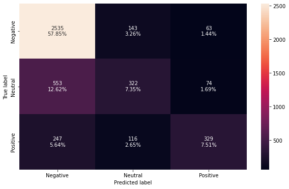

```python
# plot confusion matrix
draw_matrix(forest_tfidf,X_test_tfidf,y_test_tfidf)
```

**Observations:**

1. We see that the model gives higher accuracy on training set.
2. On the test set the model gives 72.7% accuracy, which is lesser than the model with CountVectorizer data.
3. Let us tune both models and see if the performance improves.

### Model tuning

#### Tune the RandomForestClassifier with CountVectorized dataset using hyperparameters

```python
# instantiate the model
forest_tuned_cv = RandomForestClassifier(bootstrap=True, ccp_alpha=0.0, class_weight=None,
                       criterion='gini', max_features='auto',
                       min_samples_leaf=1, min_samples_split=2,
                       min_weight_fraction_leaf=0.0, n_estimators=100,
                       oob_score=False, random_state=1, verbose=0,
                       warm_start=False)

# features and the sentiment labels as the response variable
forest_tuned_cv = forest_tuned_cv.fit(X_train_cv, y_train_cv)

# print the score
print("Score on training set")
print(forest_tuned_cv.score(X_train_cv,y_train_cv))

# check cross validation score
print("Mean CVScore on training set")
print(np.mean(cross_val_score(forest_tuned_cv, x_cv, y, cv=10)))
```

```
Score on training set
0.9950107611035023
Mean CVScore on training set
0.7247997712206876
```

#### Score the model on test set

```python
# print the score
print("Score on test set")
print(forest_tuned_cv.score(X_test_cv,y_test_cv))
```

```
Score on test set
0.7553628480146052
```

#### Plot confusion matrix

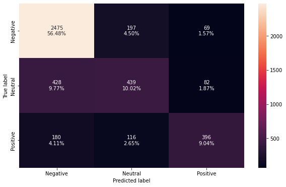

```python
# plot confusion matrix
draw_matrix(forest_tuned_cv,X_test_cv,y_test_cv)
```

**Observations:**

1. We see that the model gives higher accuracy on training set.
2. On the test set the model gives 75% accuracy.
3. Let us build another tuned model with TfIdfVectorizer data.

#### Tune the RandomForestClassifier with TFIDFVectorized dataset using hyperparameters

```python
# instantiate the model
forest_tuned_tfidf = RandomForestClassifier(bootstrap=True, ccp_alpha=0.0, class_weight=None,
                       criterion='gini', max_features='auto',
                       min_samples_leaf=1, min_samples_split=2,
                       min_weight_fraction_leaf=0.0, n_estimators=100,
                       oob_score=False, random_state=1, verbose=0,
                       warm_start=False)

# features and the sentiment labels as the response variable
forest_tuned_tfidf = forest_tuned_tfidf.fit(X_train_tfidf, y_train_tfidf)

# print the score
print("Score on training set")
print(forest_tuned_tfidf.score(X_train_tfidf,y_train_tfidf))

# check cross validation score
print("Mean CVScore on training set")
print(np.mean(cross_val_score(forest_tuned_tfidf, x_tfidf, y, cv=10)))
```

```
Score on training set
0.9939346507532772
Mean CVScore on training set
0.7132249913270139
```

#### Score the model on test set

```python
# print the score
print("Score on test set")
print(forest_tuned_tfidf.score(X_test_tfidf,y_test_tfidf))
```

```
Score on test set
0.7482884527612962
```

#### Plot confusion matrix

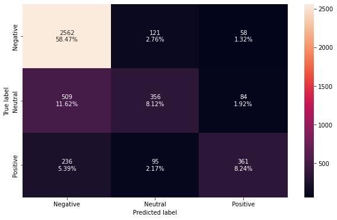

```python
# plot confusion matrix
draw_matrix(forest_tuned_tfidf,X_test_tfidf,y_test_tfidf)
```

**Observations:**

1. We see that the model gives higher accuracy on training set.
2. On the test set the model gives 74.82% accuracy, which is lesser than the tuned CountVectorized data model.
3. This means the Tuned model with CountVectorized data gives us best accuracy so far.
4. As we are aware that the data is imbalanced, we can try to normalize the data by oversampling and see if that improves the model performance.

#### Oversample data with SMOTE

```python
# instantiate SMOTE
smt = SMOTE(random_state=0)

# fit the data
X_train_SMOTE, y_train_SMOTE = smt.fit_resample(X_train_cv, y_train_cv)
```

#### Check the data after oversampling

```python
# print the distinct values
print("Split before oversampling")
print(y_train_cv.value_counts())

# print the distinct values
print("Split after oversampling")
print(y_train_SMOTE.value_counts())
```

```
Split before oversampling
negative    6418
neutral     2142
positive    1662
Name: airline_sentiment, dtype: int64
Split after oversampling
positive    6418
negative    6418
neutral     6418
Name: airline_sentiment, dtype: int64
```

#### Build RandomForest model with hyperparameters and Oversampled data

```python
# instantiate the model
forest_tuned_smote = RandomForestClassifier(bootstrap=True, ccp_alpha=0.0, class_weight=None,
                       criterion='gini', max_features='auto',
                       min_samples_leaf=1, min_samples_split=2,
                       min_weight_fraction_leaf=0.0, n_estimators=100,
                       oob_score=False, random_state=1, verbose=0,
                       warm_start=False)

# features and the sentiment labels as the response variable
forest_tuned_smote = forest_tuned_smote.fit(X_train_SMOTE, y_train_SMOTE)

# print the score
print("Score on training set")
print(forest_tuned_smote.score(X_train_SMOTE,y_train_SMOTE))

# check cross validation score
print("Mean CVScore on training set")
print(np.mean(cross_val_score(forest_tuned_smote, x_cv, y, cv=10)))
```

```
Score on training set
0.892801495793082
Mean CVScore on training set
0.7247997712206876
```

#### Score the model on test set

```python
# print the score
print("Score on test set")
print(forest_tuned_smote.score(X_test_cv,y_test_cv))
```

```
Score on test set
0.7282062984938384
```

#### Plot the confusion matrix

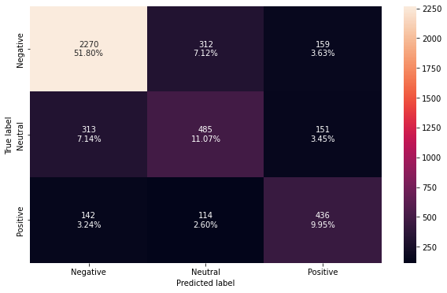

```python
# plot confusion matrix
draw_matrix(forest_tuned_smote,X_test_cv,y_test_cv)
```

**Observations:**

1. From all the models built so far we see the model built with hypertuned parameters using CountVectorized Data gives best accuracy of 75%.
2. This means the model will be able to identify correct sentiment 75% of the times.
3. We can use the same for future datasets.

#### Plot word cloud for top 40 features of the best model

#### Word cloud for top 40 features - countvectorizer

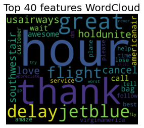

```python
# instantiate the feature from the vectorizer
all_features = count_vectorizer.get_feature_names()
top_features=''
feat=forest_tuned_cv.feature_importances_
features=np.argsort(feat)[::-1]
for i in features[0:40]:
    top_features+=all_features[i]
    top_features+=' '

#instantiate the wordcloud
wordcloud = WordCloud(background_color="black",colormap='viridis',width=3000,
                          height=2500).generate(top_features)

# display the generated image:
plt.imshow(wordcloud, interpolation='bilinear')
plt.figure(1, figsize=(20, 15), frameon='equal')
plt.title('Top 40 features WordCloud', fontsize=20)
plt.axis("off")
plt.show()
```

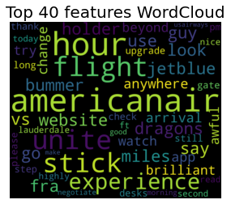

```python
# instantiate the feature from the vectorizer
all_features = tfidf_vectorizer.get_feature_names()
top_features=''
feat=forest_tuned_cv.feature_importances_
features=np.argsort(feat)[::-1]
for i in features[0:40]:
    top_features+=all_features[i]
    top_features+=' '

#instantiate the wordcloud
wordcloud = WordCloud(background_color="black",colormap='viridis',width=3000,
                          height=2500).generate(top_features)

# display the generated image:
plt.imshow(wordcloud, interpolation='bilinear')
plt.figure(1, figsize=(20, 15), frameon='equal')
plt.title('Top 40 features WordCloud', fontsize=20)
plt.axis("off")
plt.show()
```

### Summary

1. We imported tha data, observed the shape and data type of each column.
2. We applied all necessary pre processing steps to remove and alter the anamoly from the text. It helps us to explore the data more precisely.
3. We plotted the wordcloud graph of the positive and negative sentiment tweet.
4. The goal was to **build a model for text-classification**.
5. We trained the model and optimized the parameter, which **led to an increase the overall accuracy.**
6. We saw that using the above techniques, our model performed well in perspective of how text classification models perform.
7. However, **we can still increase the accuracy of our model by increasing the dataset we took into account for the model building**.
8. We can also increase the **max_feature parameter** in the vectorizer.
9. We can apply **other model tuning and hyperparameter tuning techniques, as well as other pre-processing techniques** to increase the overall accuracy even further.

### Conclusion:

```python
# Module : Introduction to Natural Language Processing
# Project: twitter us airline sentiment
# Submitted by : Ritesh Sharma
# Submission Date :11 Feb 2022
```